# 2025 Stock Assessment of Striped Marlin in the Southwest Pacific Ocean: Part II Data-moderate approach

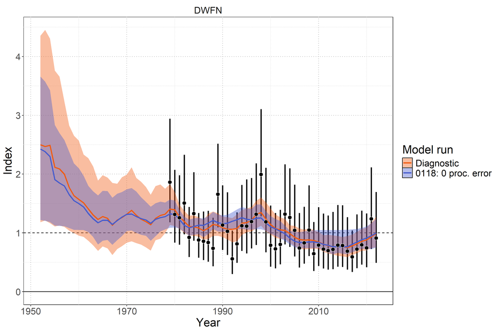

Figure 32: One-off sensitivity group: `Process error`. Model fit to standardized index data showing observations (black points with 95% error bars) and model-predictions (colored lines and shaded ribbons representing 95% credible intervals). The diagnostic model (`0100`) is shown in orange.

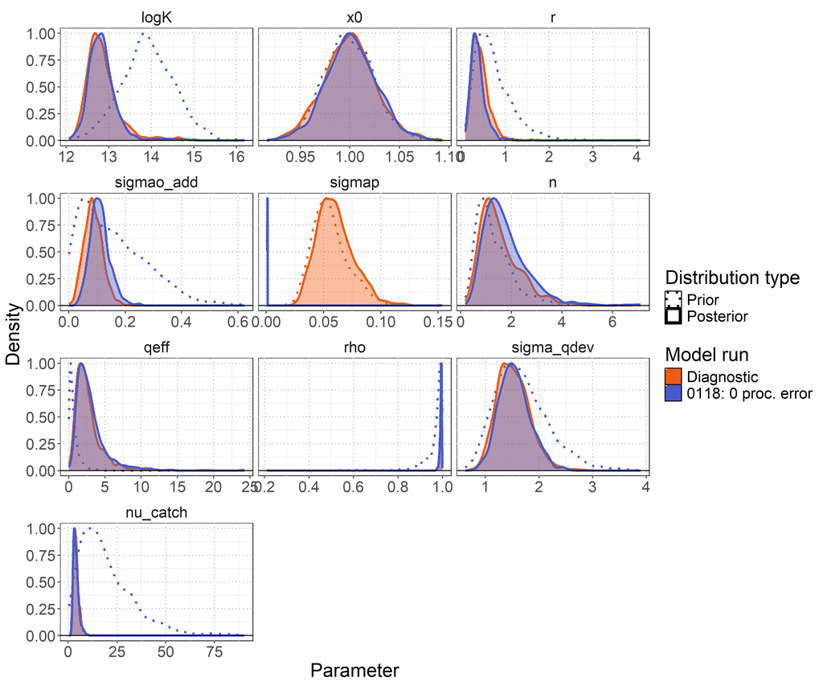

Figure 33: One-off sensitivity group: `Process error`. Prior and posterior parameter distributions showing the evolution from prior (dotted line) to posterior (shaded) distributions for leading model parameters: carrying capacity (logK), intrinsic growth rate (r), observation error (sigmao_add), process error (sigmap), shape parameter, effective catchability (qeff), autocorrelation in catchability (rho), catchability deviation variability (sigma_qdev), initial depletion (x0), and catch likelihood degrees of freedom (nu_catch). The diagnostic model (`0100`) is shown in orange.

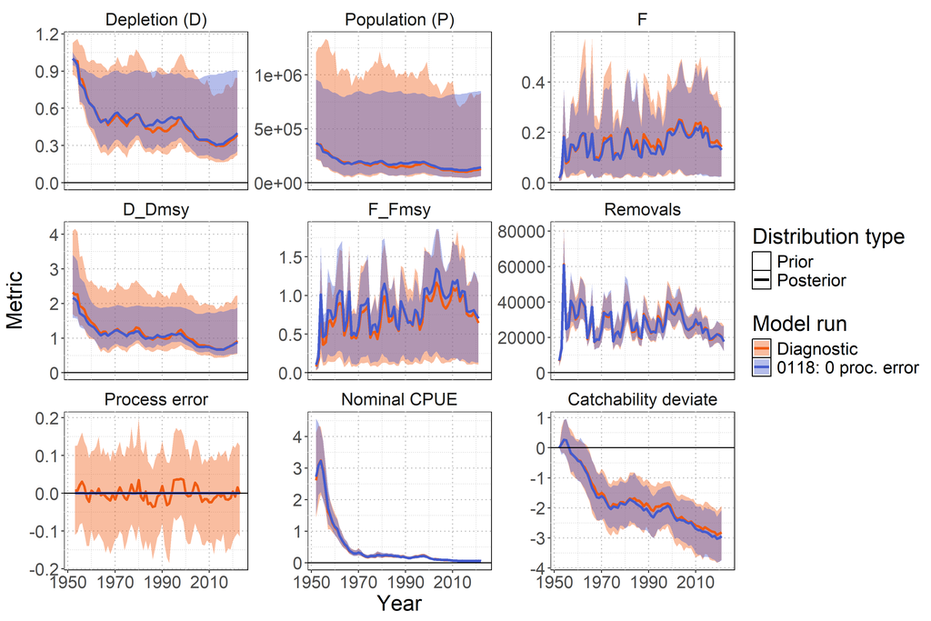

Figure 34: One-off sensitivity group: `Process error`. Posterior time series distributions for key derived quantities over time (line = median, shading = 95% credible interval): depletion (D), absolute population size in numbers (P), fishing mortality (F), stock status relative to MSY reference points ($D/D_{MSY}$, $F/F_{MSY}$), total removals in numbers, process error, nominal CPUE (numbers caught per 1000 hooks), and catchability deviates. The diagnostic model (`0100`) is shown in orange.

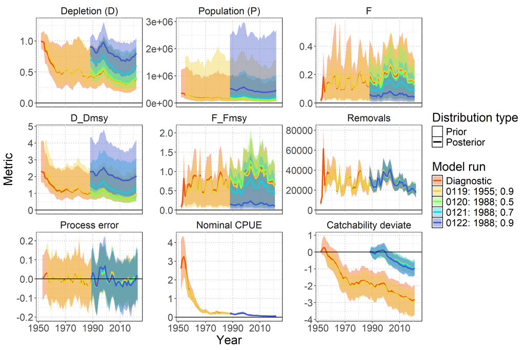

Figure 35: One-off sensitivity group: `Start year`. Posterior time series distributions for key derived quantities over time (line = median, shading = 95% credible interval): depletion (D), absolute population size in numbers (P), fishing mortality (F), stock status relative to MSY reference points ($D/D_{MSY}$, $F/F_{MSY}$), total removals in numbers, process error, nominal CPUE (numbers caught per 1000 hooks), and catchability deviates. The diagnostic model (`0100`) is shown in orange.

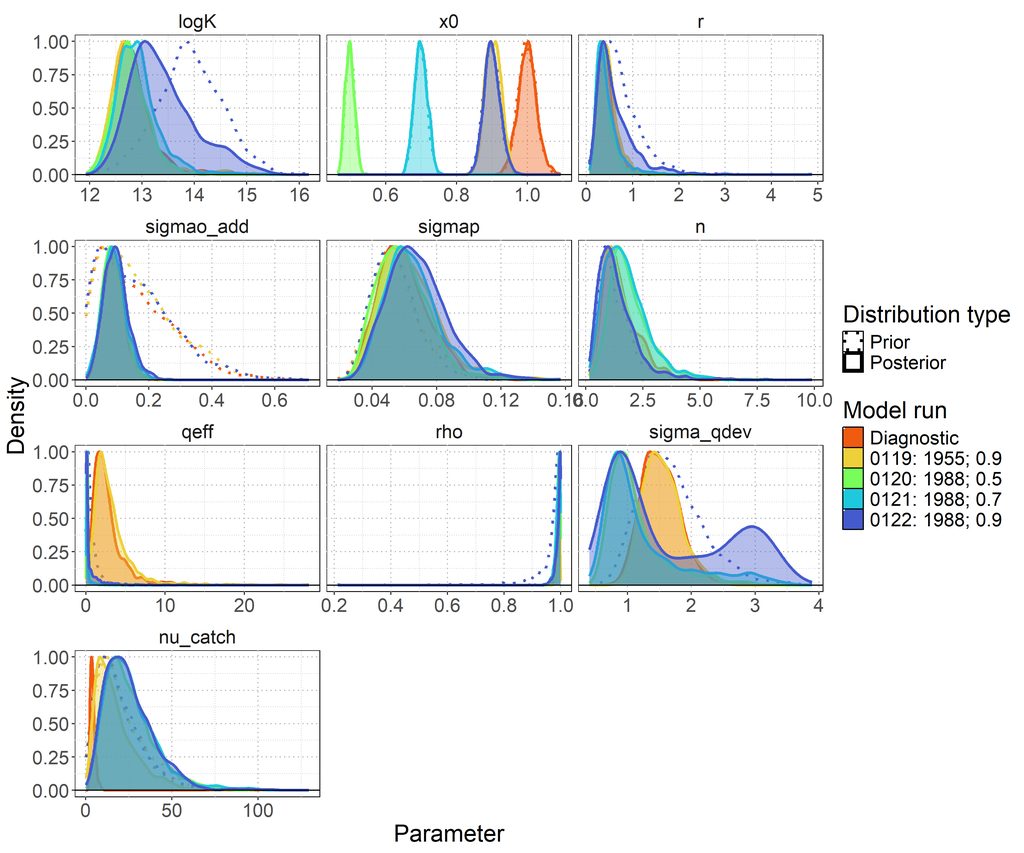

Figure 36: One-off sensitivity group: `Start year`. Prior and posterior parameter distributions showing the evolution from prior (dotted line) to posterior (shaded) distributions for leading model parameters: carrying capacity (logK), intrinsic growth rate (r), observation error (sigmao_add), process error (sigmap), shape parameter, effective catchability (qeff), autocorrelation in catchability (rho), catchability deviation variability (sigma_qdev), initial depletion (x0), and catch likelihood degrees of freedom (nu_catch). The diagnostic model (`0100`) is shown in orange.

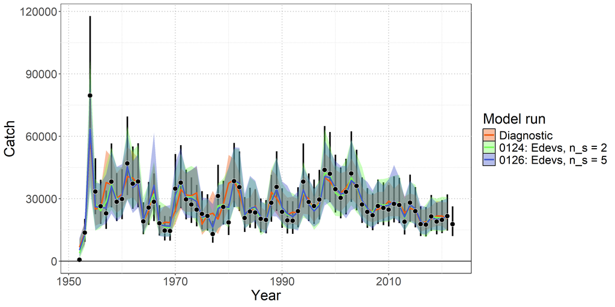

Figure 37: One-off sensitivity group: `Inclusion of effort deviates`. Model fit to catch data showing observed catch (black points with 95% error bars) and model-predicted catch (colored lines and shaded ribbons representing 95% credible intervals). The diagnostic model (`0100`) is shown in orange.

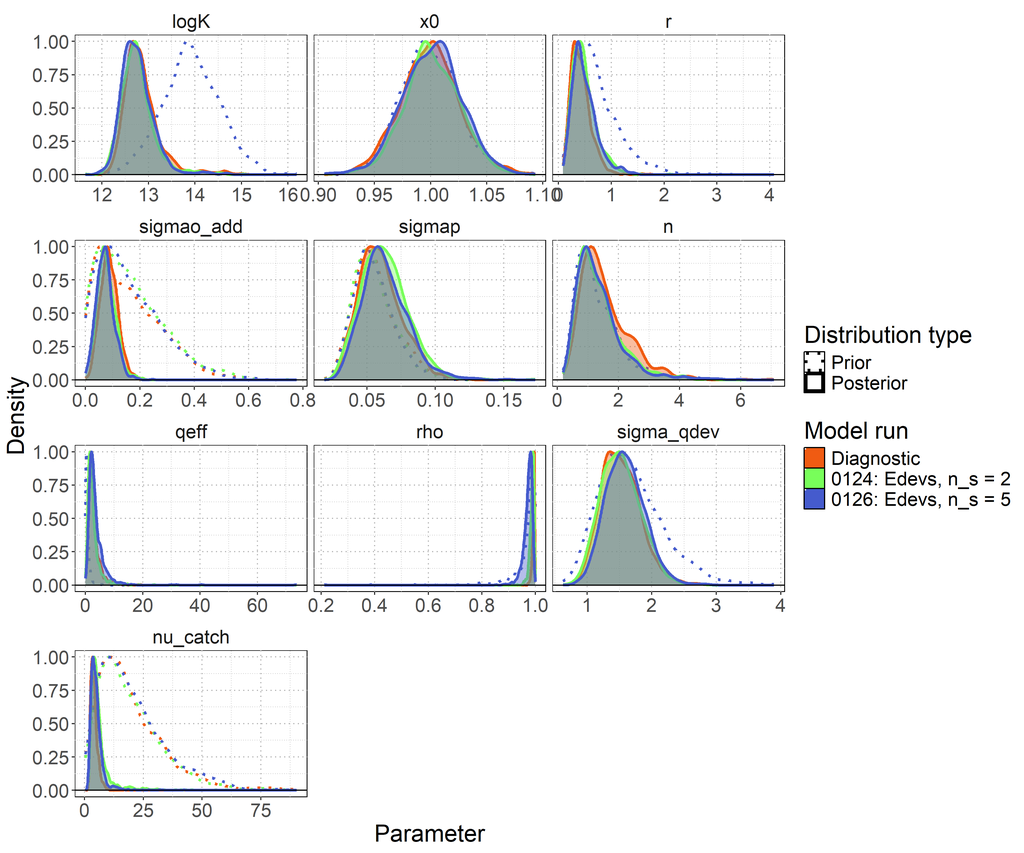

Figure 38: One-off sensitivity group: `Inclusion of effort deviates`. Prior and posterior parameter distributions showing the evolution from prior (dotted line) to posterior (shaded) distributions for leading model parameters: carrying capacity (logK), intrinsic growth rate (r), observation error (sigmao_add), process error (sigmap), shape parameter, effective catchability (qeff), autocorrelation in catchability (rho), catchability deviation variability (sigma_qdev), initial depletion (x0), and catch likelihood degrees of freedom (nu_catch). The diagnostic model (`0100`) is shown in orange.

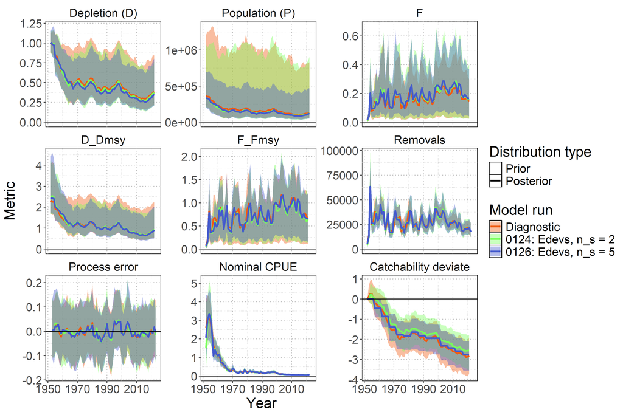

Figure 39: One-off sensitivity group: `Inclusion of effort deviates`. Posterior time series distributions for key derived quantities over time (line = median, shading = 95% credible interval): depletion (D), absolute population size in numbers (P), fishing mortality (F), stock status relative to MSY reference points ($D/D_{MSY}$, $F/F_{MSY}$), total removals in numbers, process error, nominal CPUE (numbers caught per 1000 hooks), and catchability deviates. The diagnostic model (`0100`) is shown in orange.

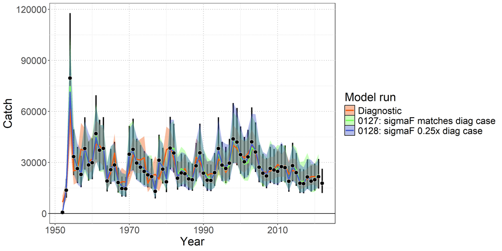

Figure 40: One-off sensitivity group: `Direct estimation of fishing mortality`. Model fit to catch data showing observed catch (black points with 95% error bars) and model-predicted catch (colored lines and shaded ribbons representing 95% credible intervals). The diagnostic model (`0100`) is shown in orange.

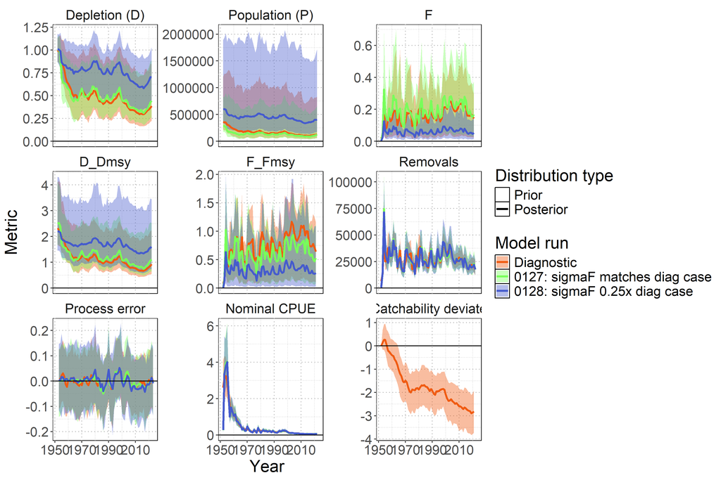

Figure 41: One-off sensitivity group: `Direct estimation of fishing mortality`. Posterior time series distributions for key derived quantities over time (line = median, shading = 95% credible interval): depletion (D), absolute population size in numbers (P), fishing mortality (F), stock status relative to MSY reference points ($D/D_{MSY}$, $F/F_{MSY}$), total removals in numbers, process error, nominal CPUE (numbers caught per 1000 hooks), and catchability deviates. The diagnostic model (`0100`) is shown in orange.

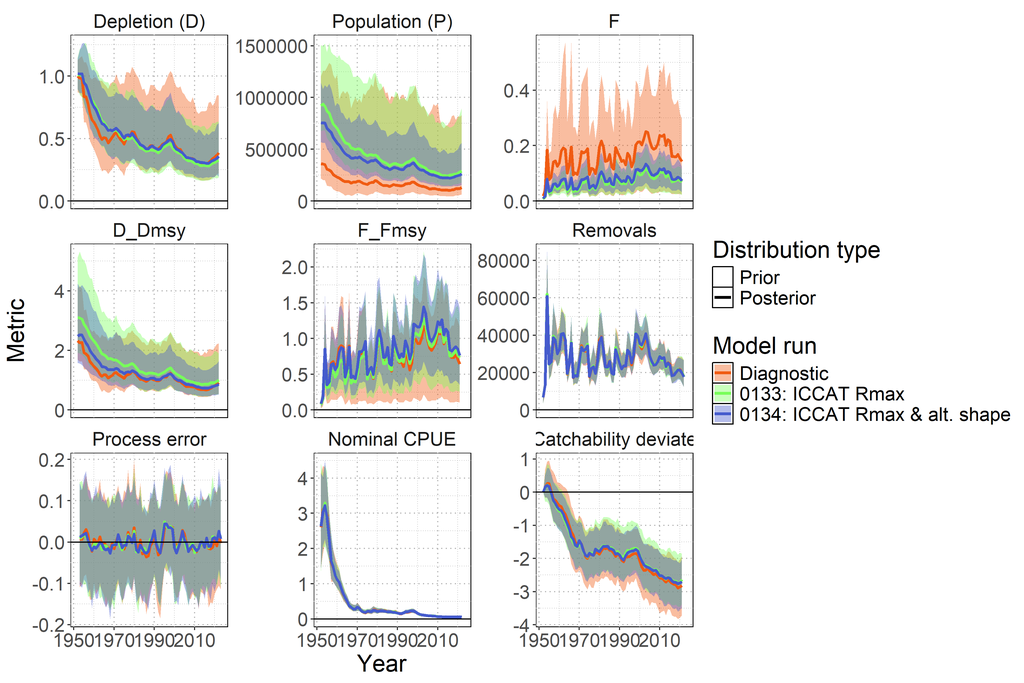

Figure 42: One-off sensitivity group: `Alternative RMax prior`. Posterior time series distributions for key derived quantities over time (line = median, shading = 95% credible interval): depletion (D), absolute population size in numbers (P), fishing mortality (F), stock status relative to MSY reference points ($D/D_{MSY}$, $F/F_{MSY}$), total removals in numbers, process error, nominal CPUE (numbers caught per 1000 hooks), and catchability deviates. The diagnostic model (`0100`) is shown in orange.

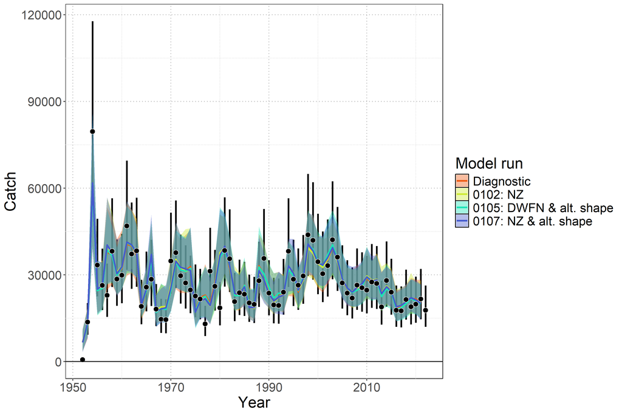

Figure 43: **Model ensemble**. Model fit to catch data showing observed catch (black points with 95% error bars) and model-predicted catch (colored lines and shaded ribbons representing 95% credible intervals). The diagnostic model (`0100`) is shown in orange.

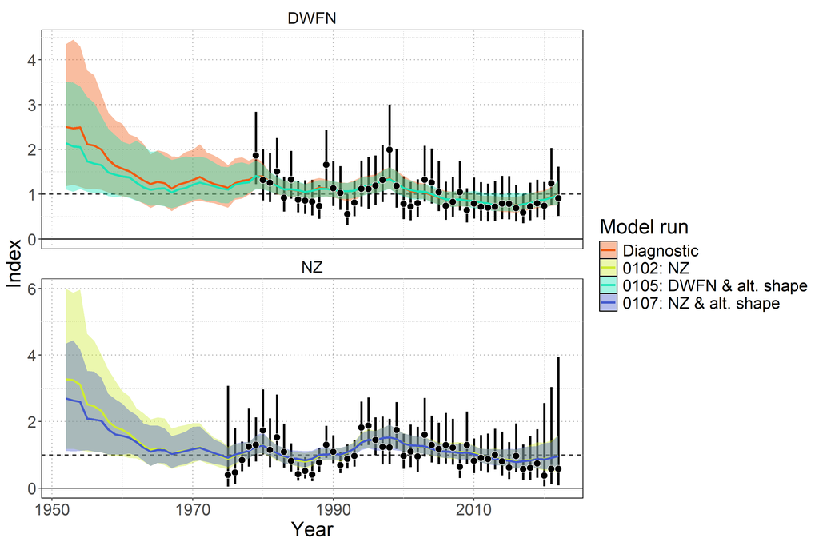

Figure 44: **Model ensemble**.. Model fit to standardized index data showing observations (black points with 95% error bars) and model-predictions (colored lines and shaded ribbons representing 95% credible intervals). The diagnostic model (`0100`) is shown in orange.

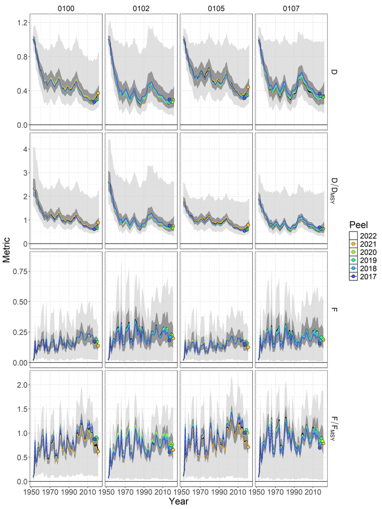

Figure 45: Retrospective analysis for the four ensemble models with respect to time series of depletion $D_t$, depletion relative to depletion at MSY $D_t/D_{MSY}$, fishing mortality $F_t$, and fishing mortality relative to the rate of fishing mortality that produces MSY $F_t/F_{MSY}$. The base model with data included through 2022 (black line – median; dark shading – 50% credible interval; light shading – 95% credible interval) is shown relative to the retrospective models. Colored lines correspond to the last year of index data and the colored point indicates the estimate in the last year of the retrospective peel.

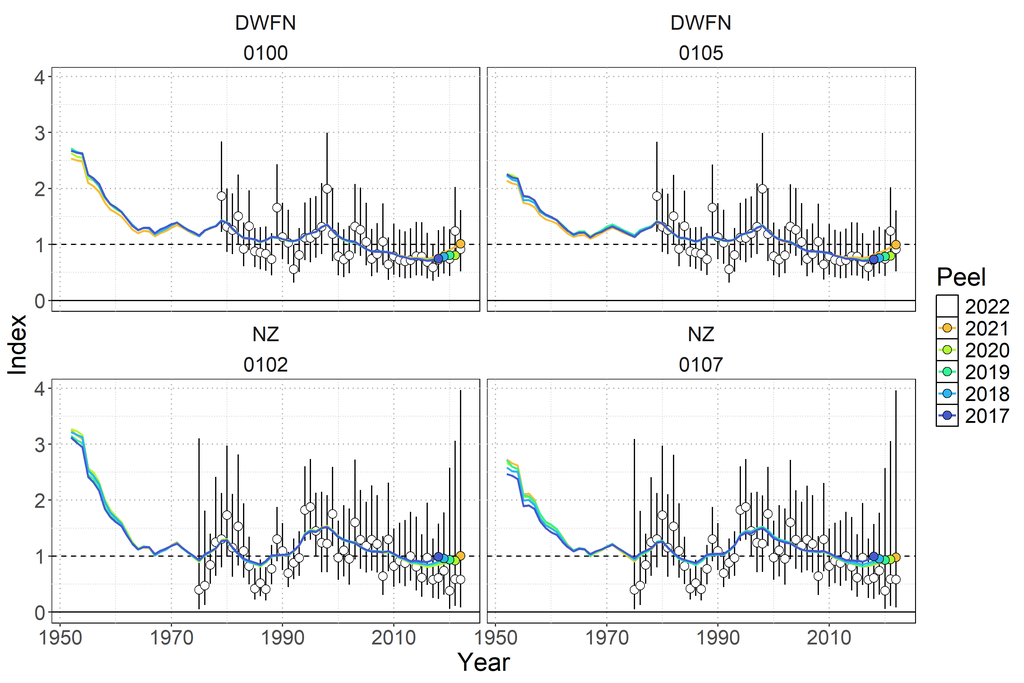

Figure 46: Standardized indices of relative abundance used in the model ensemble. Open circles show observed values (standardized to mean of 1; black horizontal line) and the vertical bars indicate the observation error (95% confidence interval). One year ahead ‘model-free’ hindcast predictions are shown by the colored lines, where the color indicates the last year of index data seen by the model. The predicted value is shown one year-ahead with the colored point.

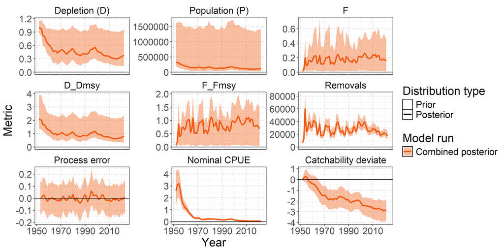

Figure 47: **Model ensemble**. Posterior time series distributions for key derived quantities over time (line = median, shading = 95% credible interval): depletion (D), absolute population size in numbers (P), fishing mortality (F), stock status relative to MSY reference points ($D/D_{MSY}$, $F/F_{MSY}$), total removals in numbers, process error, nominal CPUE (numbers caught per 1000 hooks), and catchability deviates. The model ensemble is shown in orange.

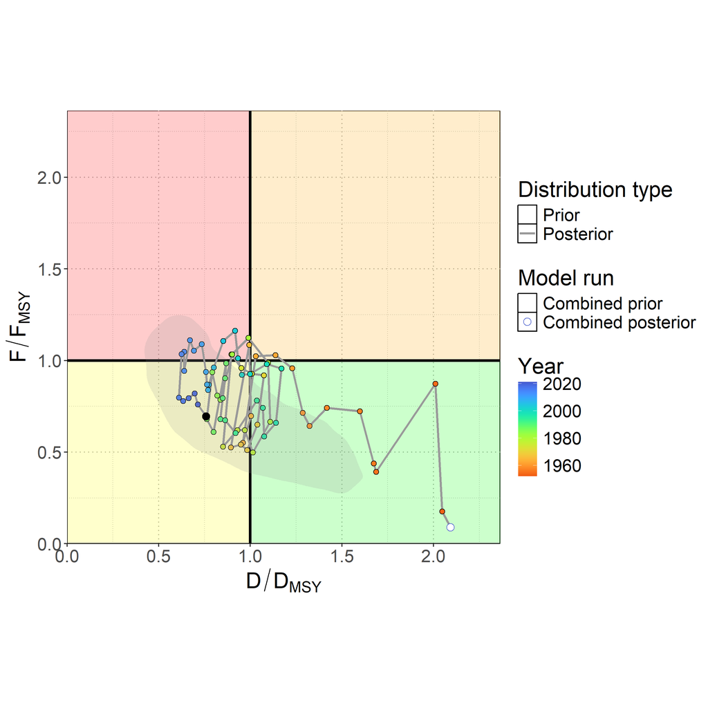

Figure 48: **Model ensemble**. Kobe plot showing the median posterior estimate of *latest* stock depletion relative to depletion at MSY ($D_{latest}/D_{MSY}$) and fishing mortality relative to MSY ($F_{latest}/F_{MSY}$). Points represent model estimates colored by year (blue $\sim 2020$, green $\sim 1985$, orange $\sim 1950$), with connecting line showing the trajectory over time. The gray shaded contour is the bi-variate 95% credible distribution around the terminal year estimate $D_{2022}/D_{MSY}$ and $F_{2021}/F_{MSY}$.

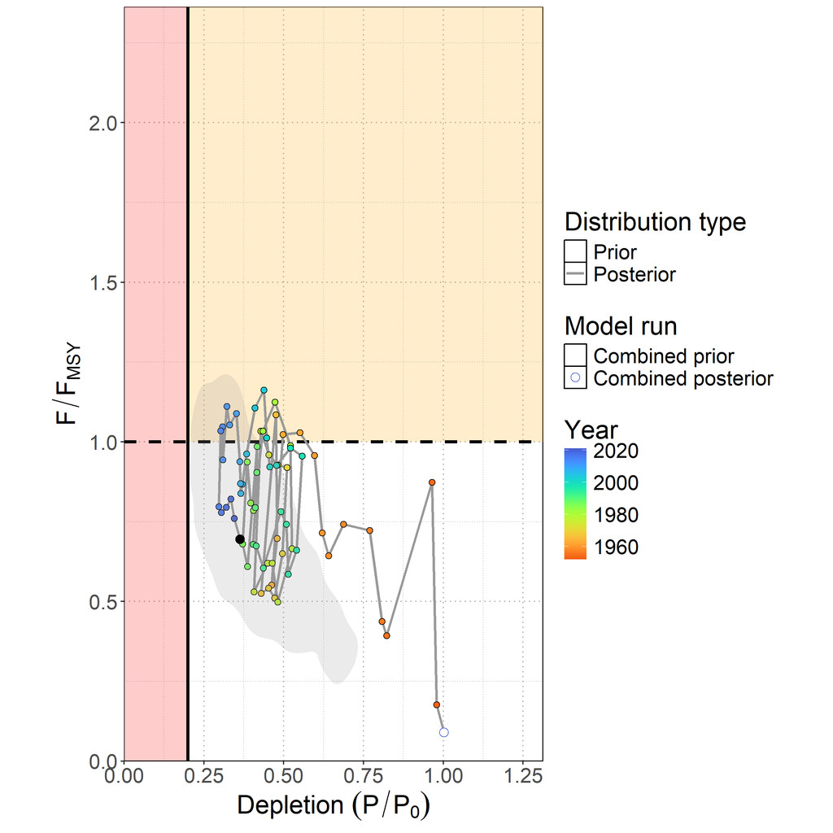

Figure 49: **Model ensemble**. Majuro plot showing the median posterior estimate of *latest* stock depletion ($D_{latest}=P_{latest}/P_0$) and fishing mortality relative to MSY ($F_{latest}/F_{MSY}$). Points represent model estimates colored by year (blue $\sim 2020$, green $\sim 1985$, orange $\sim 1950$), with connecting line showing the trajectory over time. The gray shaded contour is the bi-variate 95% credible distribution around the terminal year estimate $D_{2022}$ and $F_{2021}/F_{MSY}$.

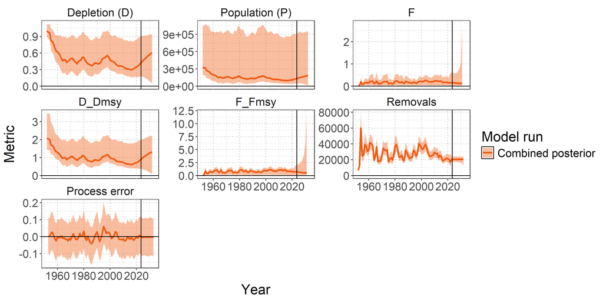

# 11 Technical Annex

Additional technical detail of population dynamics components used to solve the Euler-Lotka equation for $R_{Max}$.

## 11.1 Equilibrium Age-Structured Population Dynamics

### 11.1.1 Survival

**Survival schedule** was calculated assuming constant natural mortality:

$l_a = \begin{cases} 1 & \text{if } a = 1 \\ l_{a-1} \times \exp(-M_{ref}) & \text{if } 1 < a < A_{Max} \\ \frac{l_{A_{Max}-1}}{1-\exp(-M_{ref})} & \text{if } a = A_{Max} \text{ (plus group)} \end{cases}$

### 11.1.2 Fecundity

Reproductive output incorporated biological constraints:
$$f_a = \frac{\psi_a \times W_a \times s}{\rho}$$

where: - $\psi_a$ = proportion mature at age $a$ - $W_a$ = weight at age $a$ (proxy for reproductive capacity) - $s$ = sex ratio (proportion female) - $\rho$ = reproductive cycle (years between spawning events)

**Maturity-at-age** was derived from length-based logistic maturity:
$$\psi_L = \frac{\exp(a_{mat} + b_{mat} \times L)}{1 + \exp(a_{mat} + b_{mat} \times L)}$$
where $b_{mat} = -a_{mat}/L_{50}$, then integrated over the length-at-age distribution to obtain $\psi_a$.

**Length-at-age** followed the Francis parameterization:
$$L_a = L_1 + (L_2 - L_1) \times \frac{1 - \exp(-k(a - age_1))}{1 - \exp(-k(age_2 - age_1))}$$

with length variability modeled using probability density functions linking length bins to ages.

**Weight-at-age** used the allometric relationship:
$$W_a = a_w \times L_a^{b_w}$$

### 11.1.3 Stock-Recruitment Relationship

The slope at the origin of the stock-recruitment curve was:
$$\alpha = \frac{4h}{(1-h)\phi_0}$$

The calculation incorporated steepness ($h$) through the Beverton-Holt stock-recruitment relationship. Spawners-per-recruit in the unfished state was:
$$\phi_0 = \sum_{a=1}^{A_{Max}} l_a f_a$$

This $\alpha$ parameter links the intrinsic rate of increase to recruitment compensation, ensuring that $R_{Max}$ estimates reflect realistic population productivity under the assumed stock-recruitment dynamics.

Successful simulations (those yielding $R_{Max} > 0$ and $R_{Max} < 1.5$) were filtered to create a plausible prior distribution. The resulting distribution was fitted to a lognormal prior for use in the BSPM.

# 12 Appendix

## 12.1 Highest Density Intervals vs. Equal-Tailed Intervals

Highest density intervals (HDIs) provide an alternative to conventional equal-tailed intervals (ETIs) for characterizing uncertainty in Bayesian stock assessments. While both represent credible intervals containing a specified probability mass (e.g., 95%), they differ fundamentally in how this probability is distributed.

Equal-Tailed Intervals (ETIs) place equal probability (2.5%) in each tail of the distribution, resulting in the familiar percentile-based intervals (2.5th to 97.5th percentiles for 95% intervals). In contrast, Highest Density Intervals (HDIs) contain the 95% most probable values, defined as the shortest possible interval containing the specified probability mass. Critically, all values within an HDI are more credible (have higher probability density) than any values outside it, whereas ETIs can exclude highly probable values while including less probable ones. This is more clearly demonstrated in the following figure (Figure 51), where the ETI and HDI are presented for $D_{recent}/D_{MSY}$. As seen in panel A of Figure 51, the lower tail of the ETI inappropriately excludes high probability observations. In panel B of Figure 51, we see that all low probability observations are appropriately excluded. This shrinks the range of the credible interval, and shifts it left to exclude lower probability values in the right tail.

HDIs offer several advantages over ETIs: they are always the shortest possible credible interval (reducing perceived uncertainty), provide more intuitive interpretation by including only the most probable values, and are better suited for the right-skewed distributions common in stock assessments. However, HDIs may require explanation to stakeholders familiar with conventional intervals, and unlike ETIs, change under nonlinear transformations of the parameter.

As applied to stock assessments, HDIs typically result in narrower uncertainty intervals and can shift interval bounds toward lower values in right-skewed distributions (A. M. Edwards & Auger-Méthé, 2025). This can affect perceptions of stock status, particularly when intervals approach management reference points. The following table (Table 9) presents the median, ETI and HDI of all key stock status and management reference points for consideration by the WCPFC Scientific Committee.

Table 9: Comparison of equal-tailed intervals (ETI) and highest density intervals (HDI) for the posterior distributions of key stock status and management reference points.

| **Category** | **Metric** | **Median** | **95% ETI** | **95% HDI** |
| --- | --- | --- | --- | --- |
| **Reference points** |  |  |  |  |
| Depletion | LRP ($D_{MSY}$) | 0.48 | [0.26 – 0.7] | [0.26 – 0.7] |
| Abundance | LRP ($P_{MSY}$) | 155,183 n | [63,037 – 808,861] | [37,772 – 556,497] |
| Abundance | LRP ($0.2\times\log(K)$) | 65,041 n | [36,198 – 327,844] | [28,895 – 221,199] |
| Catch | *MSY* | 29,962 n | [25,828 – 184,069] | [23,040 – 103,619] |
| Fishing mortality | $F_{MSY}$ | 0.23 | [0.08 – 0.69] | [0.04 – 0.58] |
| **Estimates** |  |  |  |  |
| Depletion | $D_{latest}$ | 0.38 | [0.14 – 0.96] | [0.1 – 0.9] |
| Depletion | $D_{recent}$ | 0.37 | [0.15 – 0.94] | [0.11 – 0.89] |
| Abundance | $P_{latest}$ | 121,943 n | [34,067 – 1,479,253] | [8,612 – 925,445] |
| Abundance | $P_{recent}$ | 117,967 n | [34,199 – 1,442,511] | [13,983 – 911,307] |
| Catch | $C_{latest}$ | 17,488 n | [11,545 – 25,988] | [10,947 – 25,108] |
| Catch | $C_{recent}$ | 20,460 n | [16,891 – 24,770] | [16,962 – 24,792] |
| Fishing mortality | $F_{latest}$ | 0.15 | [0.01 – 0.47] | [0 – 0.4] |
| Fishing mortality | $F_{recent}$ | 0.17 | [0.01 – 0.49] | [0 – 0.42] |
| **Status** |  |  |  |  |
| Depletion | $D_{latest}/D_{MSY}$ | 0.81 | [0.32 – 2.36] | [0.24 – 2.02] |
| Depletion | $D_{recent}/D_{MSY}$ | 0.77 | [0.33 – 2.3] | [0.24 – 1.95] |
| Fishing mortality | $F_{latest}/F_{MSY}$ | 0.69 | [0.05 – 1.51] | [0.01 – 1.35] |
| Fishing mortality | $F_{recent}/F_{MSY}$ | 0.77 | [0.05 – 1.51] | [0.02 – 1.34] |

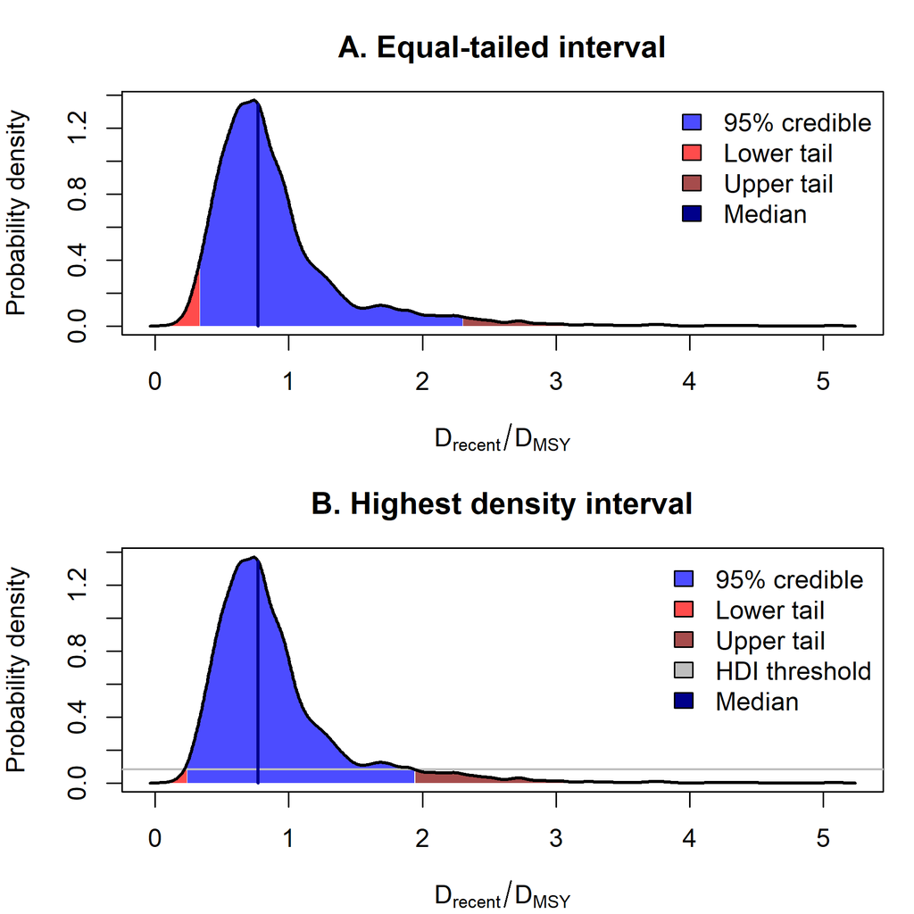

Figure 51: Comparison of equal-tailed intervals (ETI) and highest density intervals (HDI) for the posterior distribution of recent depletion relative to MSY ($D_{recent}/D_{MSY}$). Panel A shows the 95% ETI with equal probability (2.5%) in each tail. Panel B shows the 95% HDI, which contains the most probable values and is bounded by the horizontal threshold line (gray) where all values above have higher probability density than values below.

## Footnotes

[^1]: The Stan code for the diagnostic model `bspm_estqsimple_softdep_fullmvprior_x0_sttgamma_flexsigmaC_OPT` is publicly available on [GitHub](https://github.com/N-DucharmeBarth-NOAA/2025-swpo-mls-bspm/blob/main/code/Stan/bspm_estqsimple_softdep_fullmvprior_x0_sttgamma_flexsigmaC_OPT.stan).
[^2]: When input in the model the raw input effort, defined as *hundred hooks* in the WCPFC database is divided by `1e6` to re-scale catchability so that it is numerically on the same scale as other estimated parameters. This improves convergence of the HMC sampling of the posterior distribution.
[^3]: There are 71 total periods in the model period 1952-2022 and fishing mortality is not estimated in the terminal year.
[^4]: As $\nu_c \to \infty$ the likelihood equation converges to the lognormal distribution $\text{Lognormal}\left(\log(Removals_t) - \frac{\sigma_{C,t}^2}{2}, \sigma_{C,t}\right)$
[^5]: The R code for the simulation `01-01-define-rmax-prior.r` is publicly available on [GitHub](https://github.com/N-DucharmeBarth-NOAA/2025-swpo-mls-bspm/blob/main/code/R/01-01-define-rmax-prior.r).
[^6]: This is applied in the R script `03-06-new-logK-prior-pushforward-bspm_estqsimple_softdep_mvprior_x0.r` lines 64-92 which is publicly available on [GitHub](https://github.com/N-DucharmeBarth-NOAA/2025-swpo-mls-bspm/blob/main/code/R/03-06-new-logK-prior-pushforward-bspm_estqsimple_softdep_mvprior_x0.r).
[^7]: The upper limit of population scale is typically more challenging to estimate than the lower population limit as population scales of infinite sizes can support any observed catches. However, there typically is a hard floor to population scale in that it must be sufficiently large to maintain a population that produces the time series of observed catches.
[^8]: Note that depletion for the surplus production model is a *static* depletion defined relative to total unfished numbers $D_t=P_t/P_0$; where $P_t$ is the total population level in numbers at time $t$, and $P_0 = K$ the unfished population numbers or carrying capacity. This is different from the *dynamic* depletion of spawning biomass $SB_t/SB_{t,F=0}$ that is typically reported from integrated age-structured models such as MULTIFAN-CL or Stock Synthesis (Methot Jr. & Wetzel, 2013).
[^9]: Most surplus production models subtract observed catch directly (Best & Punt, 2020; Kim & Neubauer, 2025; Millar & Meyer, 2000)
[^10]: North Island of New Zealand